# MTH 209 Data Manipulation and Management

# Data Frames - 1

A data frame is like a matrix. It has a two-dimensional data structure. But it differs from a matrix since the data type of each column could be different. Technically, a data frame is a list, with the components that list being equal-length vectors.

- Creating Data Frames

```r
kids <- c("Vicky", "Patrick", "Jasmine")
ages <- c(14, 10, 8)
# create the data frame using kids and ages
df <- data.frame(kids, ages, stringsAsFactors = F)
df
```

```
##      kids ages
## 1   Vicky   14
## 2 Patrick   10
## 3 Jasmine    8
```

We can include columns directly in the data frame when creating it as well.

```r
data.frame(kids = c("Vicky", "Patrick", "Jasmine"), ages = c(14, 10, 8), stringsAsFactors = F)
```

```
##      kids ages
## 1   Vicky   14
## 2 Patrick   10
## 3 Jasmine    8
```

# Data Frames - 2

- Accessing Data Frames

There are multiple ways to access a data frame.

```r
df[[1]] # list-like
```

```
## [1] "Vicky"   "Patrick" "Jasmine"
```

```r
df$kids # component name
```

```
## [1] "Vicky"   "Patrick" "Jasmine"
```

```r
df[,1]  # matrix-like
```

```
## [1] "Vicky"   "Patrick" "Jasmine"
```

```r
df[, "kids"] # matri-like with the column name
```

```
## [1] "Vicky"   "Patrick" "Jasmine"
```

**Question:** consider four ways to access the first column of the data frame above, which way(s) would generally considered to be clear and safer than others?

# Data Frames - 3

- Checking Data Structures

We can use str() function to display the structure of an arbitrary R object.

```r
str(df)
```

```
## 'data.frame':    3 obs. of  2 variables:
##  $ kids: chr  "Vicky" "Patrick" "Jasmine"
##  $ ages: num  14 10 8
```

- Other Matrix-Like Operations

Many matrix operations apply to data frames as well. We will use a R built-in dataset ToothGrowth. First, we use the head() function to see the first six rows of the data.

```r
head(ToothGrowth)
```

```
##    len supp dose
## 1  4.2   VC  0.5
## 2 11.5   VC  0.5
## 3  7.3   VC  0.5
## 4  5.8   VC  0.5
## 5  6.4   VC  0.5
## 6 10.0   VC  0.5
```

# Data Frames - 4

Use ToothGrowth data to answer the following questions.

1. Find a data frame that contains observations from the 3rd row to 7th row in ToothGrowth.
2. Find a data frame that contains values from 3rd row to 7th row for the 3rd column in ToothGrowth.
3. Find a data frame that only contains observations such that their tooth length (*len*) are smaller than the mean tooth length of guinea pigs in ToothGrowth.

# Factors & Tables - 1

Since we have introduced factors in Lesson 2, we will focus the concepts about tables. Before we talk about how we could work with tables, let’s see an example that demonstrates how we can rearrange the levels in a factor.

```r
set.seed(2022)
seasons <- factor(sample(c("Spring", "Summer", "Fall"), 1000, replace = T))
levels(seasons)
```

```
## [1] "Fall"   "Spring" "Summer"
```

Here, we can see that the order of levels in *seasons* is not *Spring*, *Summer*, *Fall*, which didn’t reflect the time order.

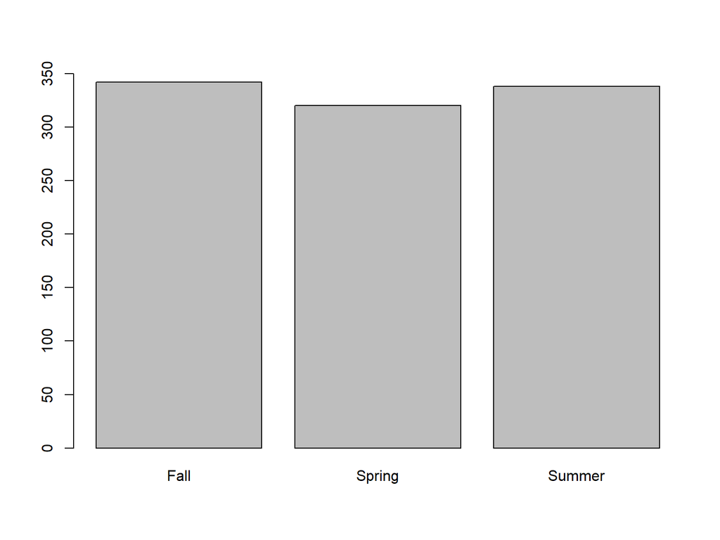

```r
barplot(table(seasons), ylim=c(0, 350))
```

# Factors & Tables - 2

Continue from the previous slide, we want to change the order of levels in *seasons*.

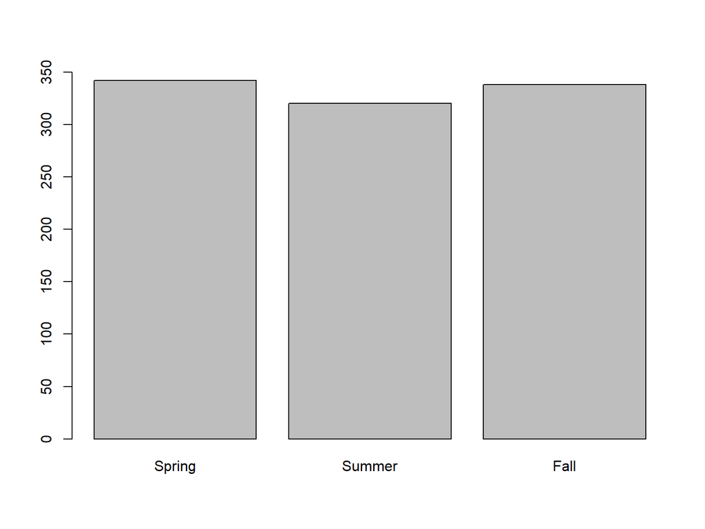

```r
seasons <- factor(seasons, labels = c("Spring", "Summer", "Fall"))
barplot(table(seasons), ylim=c(0, 350))
```

Now, if we want to add another category *Winter* in *seasons*, an intuitive way is to combine the previous vector with the new vector. But quickly we find that the data type of the new object is changed to “character”.

```r
winters <- rep("Winter", 10)
all_seasons <- c(seasons, winters)
class(all_seasons)
```

```
## [1] "character"
```

# Factors & Tables - 3

If we look into this further by checking the frequency distribution of the data, we find that the first three categories were changed to the characters of 1, 2, and 3.

```r
table(all_seasons)
```

```
## all_seasons
##      1      2      3 Winter
##    342    320    338     10
```

**Question:** How to deal with this issue?

We should change the data type of *winters* to factor.

```r
winters <- as.factor(winters)
all_seasons <- c(seasons, winters)
class(all_seasons)
```

```
## [1] "factor"
```

We can add a new level to a factor object if needed.

```r
levels(seasons) <- c(levels(seasons), "Winter")
```

# Factors & Tables - 4

On the previous slides, we used the table() function to find frequency distribution of a categorical variable. In fact, this function can be used to create a contingency table of two categorical variables.

```r
set.seed(2022)
Grade <- sample(c(LETTERS[1:4], "F"), 100, replace=T)
Sex <- sample(c("Male", "Female"), 100, replace=T, prob=c(0.4, 0.6))
table(Grade, Sex)
```

```
##      Sex
## Grade Female Male
##     A     12    7
##     B     10   11
##     C     11    9
##     D     11    9
##     F     16    4
```

**Note:** Similar to data frames, most matrix/array operations can be used on tables.

# README

You can utilize the following single character keyboard shortcuts to enable alternate display modes (Xie, Allaire, and Grolemund (2018)):

- A: Switches show of current versus all slides (helpful for printing all pages)
- B: Make fonts large
- c: Show table of contents
- S: Make fonts smaller

Matloff, Norman. 2011. *The Art of r Programming: A Tour of Statistical Software Design*. No Starch Press.

Xie, Yihui, Joseph J Allaire, and Garrett Grolemund. 2018. *R Markdown: The Definitive Guide*. CRC Press.